# LOTR Network

Christian

2022-07-04

# One Network Visualisation to Rule Them

## Description

This Rmarkdown document will detail the process behind the visualisations made from this project. These include

- Degree centrality for the Two Towers
- Betweeness centrality for the Two Towers
- Closeness centrality for the Two Towers
- Degree centrality for the combined books
- Betweeness centrality for the combined books
- Closeness centrality for the combined books
- Evolution of degree centrality accross the three books

## Degree centrality: The Two Towers

For this plot we’ll import the data, take the first 10 characters by centrality, and visualise the data in a barplot

[figure not shown]

```r
dc_tt <- read_csv('Centrality Measures TT/Centrality.csv') %>%
  rename(character = ...1) %>%
  arrange(desc(centrality)) %>%
  slice_head(n = 10)

tt_centrality <- ggplot(dc_tt,
                        aes(x = reorder(character, desc(centrality)),
                        y = centrality,
                        fill = character)) +

  geom_bar(stat = "identity") +

  scale_y_continuous(
    limits = c(0,0.525),
    expand = c(0,0)
  ) +

  labs(x = NULL, y = "Centrality", title = "Character Importance (The Two Towers): Centrality", subtitle = "Top 10 most important characters in The Two Towers, as measured by degree centrality") +

  theme_classic() +

  theme(
    legend.position = "none",
    panel.grid.major.y = element_line(color = "grey",
                                          size = 0.1,
                                          linetype = 1),
    panel.grid.minor.y = element_line(color = "grey",
                                          size = 0.1,
                                          linetype = 1)
  )

ggsave("Images/tt_centality.png", height = 4.47, width = 7.2)

tt_centrality
```

## Betweenness centrality: The Two Towers

This code will take the top 10 characters by betweenness centrality and visualise those using a bar chart.

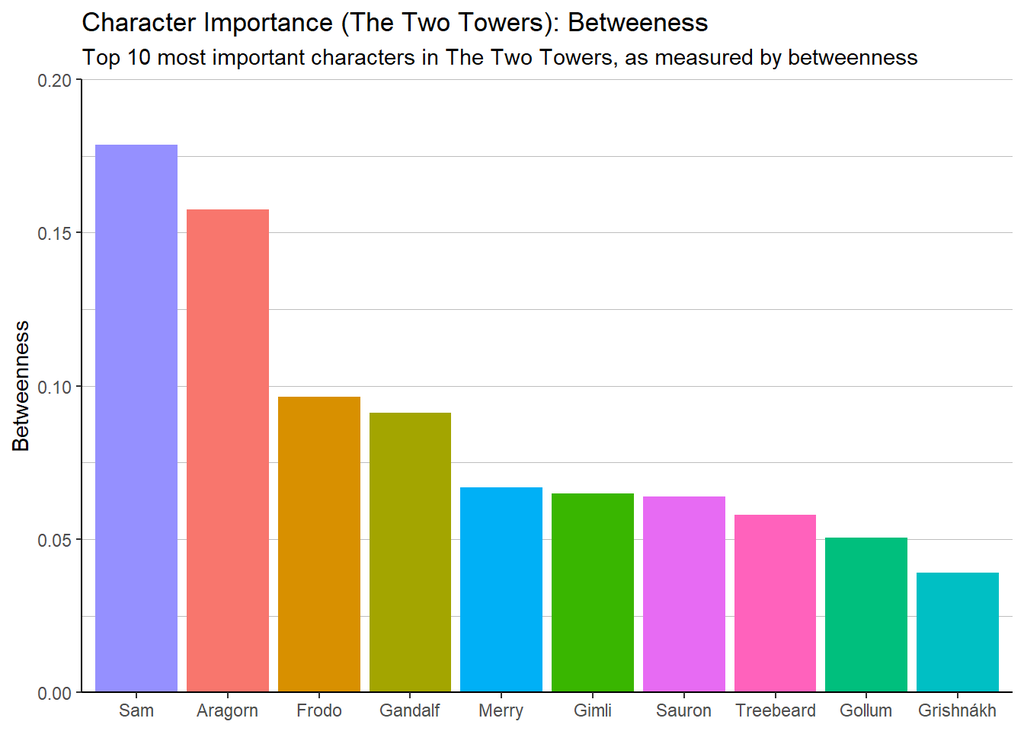

```r
bc_tt <- read_csv('Centrality Measures TT/Betweenness.csv') %>%
  rename(character = ...1) %>%
  arrange(desc(centrality)) %>%
  slice_head(n = 10)

tt_betweenness <- ggplot(bc_tt,
                        aes(x = reorder(character, desc(centrality)),
                        y = centrality,
                        fill = character)) +

  geom_bar(stat = "identity") +

  scale_y_continuous(
    limits = c(0,0.2),
    expand = c(0,0)
  ) +

  labs(x = NULL, y = "Betweenness", title = "Character Importance (The Two Towers): Betweeness", subtitle = "Top 10 most important characters in The Two Towers, as measured by betweenness") +

  theme_classic() +

  theme(
    legend.position = "none",
    panel.grid.major.y = element_line(color = "grey",
                                          size = 0.1,
                                          linetype = 1),
    panel.grid.minor.y = element_line(color = "grey",
                                          size = 0.1,
                                          linetype = 1)
  )

ggsave("Images/tt_betweenness.png", height = 4.47, width = 7.2)

tt_betweenness
```

## Closeness centrality: The Two Towers

This code will take the top 10 characters by closeness centrality and visualise those using a bar chart.

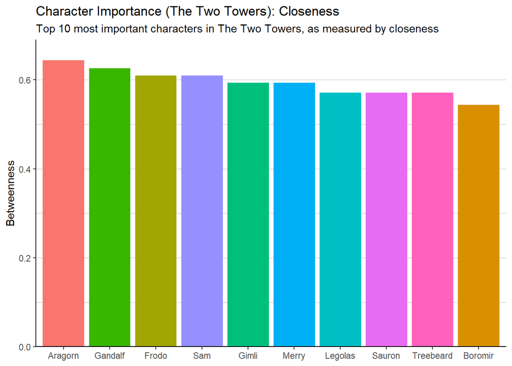

```r
cc_tt <- read_csv('Centrality Measures TT/Closeness.csv') %>%
  rename(character = ...1) %>%
  arrange(desc(centrality)) %>%
  slice_head(n = 10)

tt_closeness <- ggplot(cc_tt,
                        aes(x = reorder(character, desc(centrality)),
                        y = centrality,
                        fill = character)) +

  geom_bar(stat = "identity") +

  scale_y_continuous(
    limits = c(0,0.69),
    expand = c(0,0)
  ) +

  labs(x = NULL, y = "Betweenness", title = "Character Importance (The Two Towers): Closeness", subtitle = "Top 10 most important characters in The Two Towers, as measured by closeness") +

  theme_classic() +

  theme(
    legend.position = "none",
    panel.grid.major.y = element_line(color = "grey",
                                          size = 0.1,
                                          linetype = 1),
    panel.grid.minor.y = element_line(color = "grey",
                                          size = 0.1,
                                          linetype = 1)
  )

ggsave("Images/tt_closeness.png", height = 4.47, width = 7.2)

tt_closeness
```

## Degree centrality: All Books

Next, we’ll apply all of the centrality measures to the relationships from the combined books. Starting with the degree centrality measure.

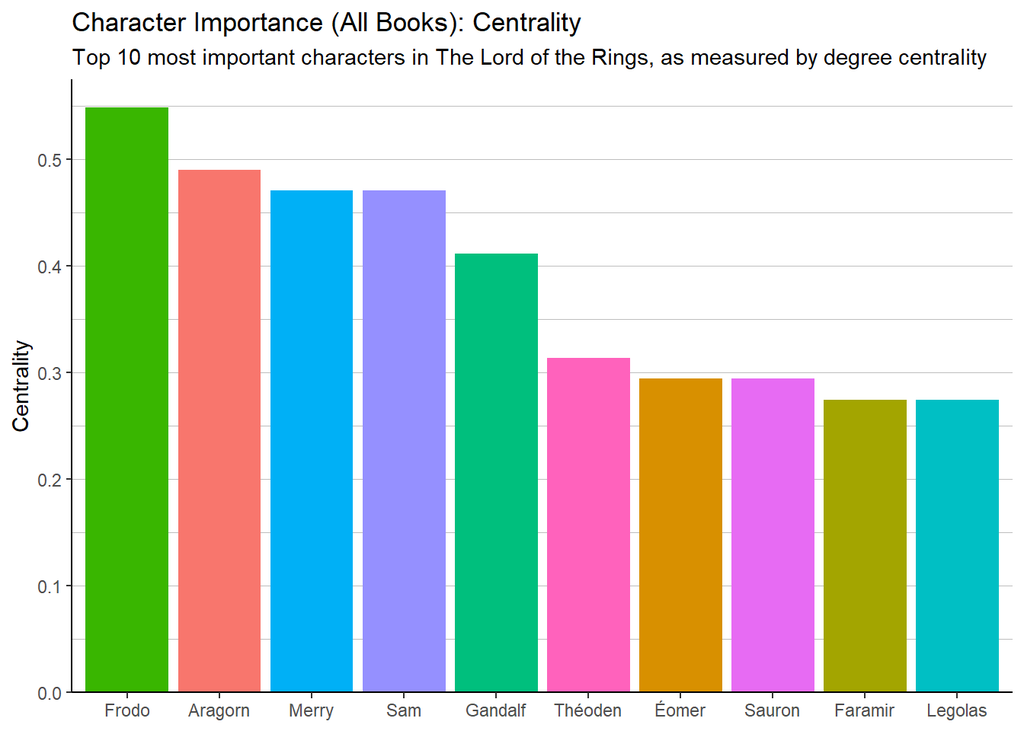

```r
dc_all <- read_csv('Centrality Measures All/Centrality.csv') %>%
  rename(character = ...1) %>%
  arrange(desc(centrality)) %>%
  slice_head(n = 10)

all_centrality <- ggplot(dc_all,
                        aes(x = reorder(character, desc(centrality)),
                        y = centrality,
                        fill = character)) +

  geom_bar(stat = "identity") +

  scale_y_continuous(
    limits = c(0,0.575),
    expand = c(0,0)
  ) +

  labs(
    x = NULL,
    y = "Centrality",
    title = "Character Importance (All Books): Centrality",
    subtitle = "Top 10 most important characters in The Lord of the Rings, as measured by degree centrality"
  ) +

  theme_classic() +

  theme(
    legend.position = "none",
    panel.grid.major.y = element_line(color = "grey",
                                          size = 0.1,
                                          linetype = 1),
    panel.grid.minor.y = element_line(color = "grey",
                                          size = 0.1,
                                          linetype = 1)
  )

ggsave("Images/all_centality.png", height = 4.47, width = 7.2)

all_centrality
```

## Betweenness centrality: All Books

This code will take the top 10 characters by betweenness centrality and visualise those using a bar chart.

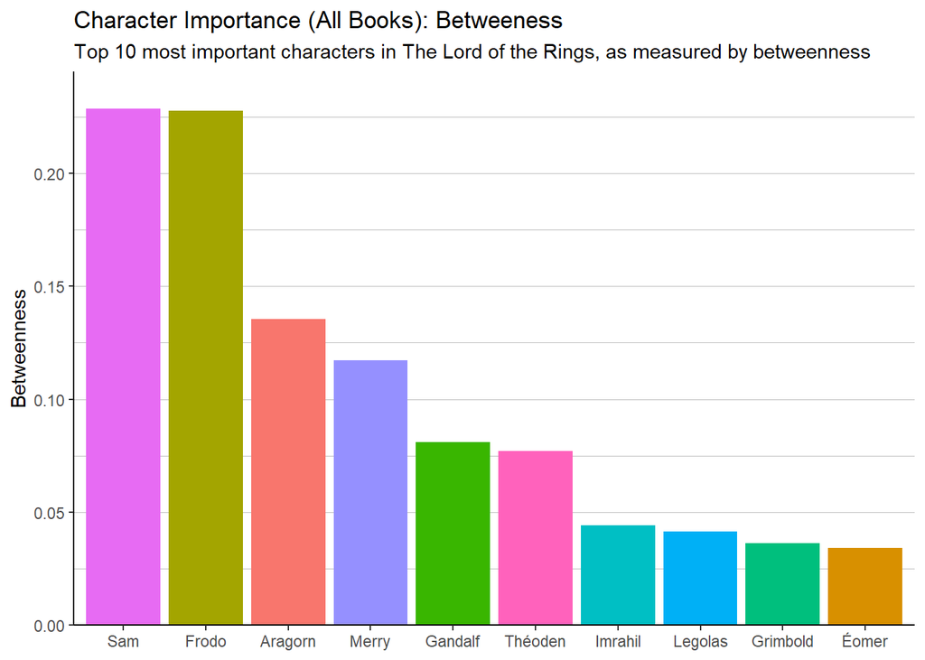

```r
bc_all <- read_csv('Centrality Measures All/Betweenness.csv') %>%
  rename(character = ...1) %>%
  arrange(desc(centrality)) %>%
  slice_head(n = 10)

all_betweenness <- ggplot(bc_all,
                        aes(x = reorder(character, desc(centrality)),
                        y = centrality,
                        fill = character)) +

  geom_bar(stat = "identity") +

  scale_y_continuous(
    limits = c(0,0.245),
    expand = c(0,0)
  ) +

  labs(x = NULL,
       y = "Betweenness",
       title = "Character Importance (All Books): Betweeness",
       subtitle = "Top 10 most important characters in The Lord of the Rings, as measured by betweenness"
  ) +

  theme_classic() +

  theme(
    legend.position = "none",
    panel.grid.major.y = element_line(color = "grey",
                                          size = 0.1,
                                          linetype = 1),
    panel.grid.minor.y = element_line(color = "grey",
                                          size = 0.1,
                                          linetype = 1)
  )

ggsave("Images/all_betweenness.png", height = 4.47, width = 7.2)

all_betweenness
```

## Closeness centrality: All Books

This code will take the top 10 characters by closeness centrality and visualise those using a bar chart.

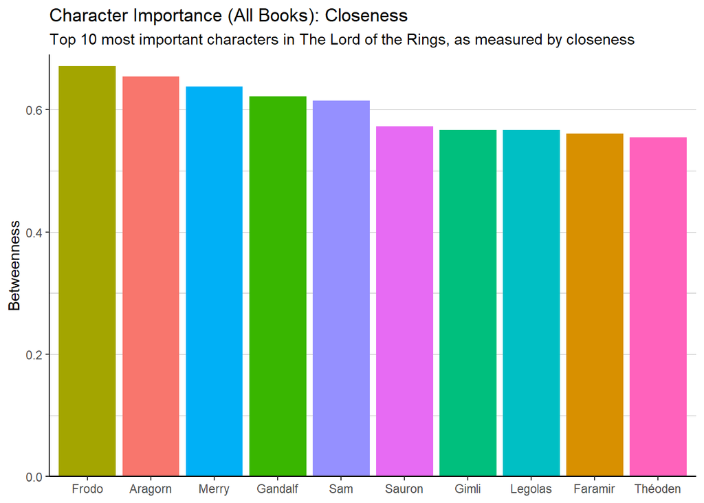

```r
cc_all <- read_csv('Centrality Measures All/Closeness.csv') %>%
  rename(character = ...1) %>%
  arrange(desc(centrality)) %>%
  slice_head(n = 10)

all_closeness <- ggplot(cc_all,
                        aes(x = reorder(character, desc(centrality)),
                        y = centrality,
                        fill = character)) +

  geom_bar(stat = "identity") +

  scale_y_continuous(
    limits = c(0,0.69),
    expand = c(0,0)
  ) +

  labs(x = NULL, y = "Betweenness", title = "Character Importance (All Books): Closeness", subtitle = "Top 10 most important characters in The Lord of the Rings, as measured by closeness") +

  theme_classic() +

  theme(
    legend.position = "none",
    panel.grid.major.y = element_line(color = "grey",
                                          size = 0.1,
                                          linetype = 1),
    panel.grid.minor.y = element_line(color = "grey",
                                          size = 0.1,
                                          linetype = 1)
  )

ggsave("Images/all_closeness.png", height = 4.47, width = 7.2)

all_closeness
```

## Importance over the series

Finally we will visualise the trend in character importance accross the series

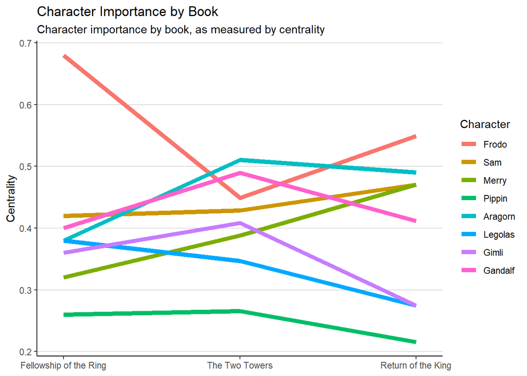

```r
evol_all <- read_csv('Centrality Measures All/Importance.csv') %>%
  mutate(Book = c("Fellowship of the Ring", "The Two Towers", "Return of the King")) %>%
  select(Book, Frodo, Sam, Merry, Pippin, Aragorn, Legolas, Gimli, Gandalf) %>%
  melt(Value.name = "centrality") %>%
  rename(character = variable, centrality = value)


evol_plot <- ggplot(evol_all,
                    aes(
                      x = factor(Book, levels = c("Fellowship of the Ring", "The Two Towers", "Return of the King")),
                      y = centrality,
                      group = character,
                      color = character)
                    ) +

  scale_x_discrete(expand = c(0.05,0.05)) +

  #scale_y_continuous(limits = c(0, 0.72)) +

  geom_line(size = 2) +

  labs(x = NULL, y = "Centrality", title = "Character Importance by Book", subtitle = "Character importance by book, as measured by centrality", color = "Character") +

  theme_classic() +

  theme(

    panel.grid.major.y = element_line(color = "grey",
                                          size = 0.1,
                                          linetype = 1)
    )


ggsave("Images/all_evolve.png", height = 4.47, width = 7.2)

evol_plot
```